# 📘 Structure of Quarto notebooks

Hélène Langet

helene.langet@swisstph.ch

Swiss TPH Research-IT

Zhihan Zhu

zhihan.zhu@swisstph.ch

Swiss TPH Research-IT

2024-11-25

## 1 Learning objectives 🎯

1. Understand the structure of the Quarto notebook
2. Understand the difference and relationships between notebooks and rendered documents

## 2 Quarto notebooks vs. rendered documents

A Quarto notebook and its corresponding rendered document(s) serve different purposes but are closely connected.

- The **Quarto notebook** is the **source document** where content is defined.
- The **rendered document** is the **output** generated from the Quarto notebook. Common rendered document formats include:
  - HTML for interactive web-based reports.
  - PDF for professional and printable documents.
  - Word for editable text-based outputs.

## 3 Structure of a Quarto notebook

There are three basic components to a Quarto document.

- Header
- Markdown text
- Code

At the top of the Quarto notebook, you will see something that looks as follows:

```yaml
---
title: "Untitled"
format: html
---
```

This section is called the **YAML header** and it contains commands and metadata about the Quarto document. There is only one unique header in a Quarto document and it is always surrounded by `---` lines on the top and bottom of the section.

YAML is a data format that has the form of a **key: value pairing** to store data. The keys in this case are *title* and *format*; they are are some of many settings that Quarto has available to use. The values are those that follow the key (e.g., “Untitled” for *title*). These key data are used to store the settings that Quarto will use to render the output document.

In white background areas, any text will appear as regular text in the final report. This is actually a markup language, which can have formatting such as headings, italics, bold, numbers, and bullets.

Code chunks, typically shown within gray backgrounds, execute commands in Quarto. In the example provided, R code is being run within these chunks. These commands may handle data processing, cleaning, or the generation of visual outputs that are integrated into the final document.

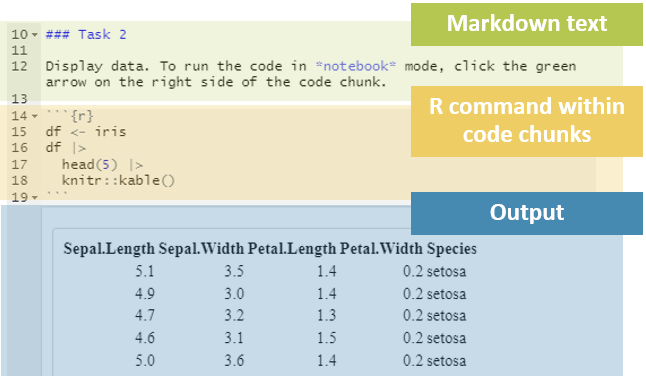

## 4 Structure of a rendered document

The rendered document translates the notebook’s structure, content, and code outputs into a polished, static format for presentation or sharing.

## 5 References

- [The Epidemiologist R Handbook](https://epirhandbook.com)
- [Analytically reproducible documents](https://r-cubed-v2.rostools.org/reproducible-documents)

[figure not shown]

Quarto training for R